# KG help

Gina Nichols

4/13/2020

Install the R package with the data

```r
#devtools::install_github("vanichols/PFIweeds2020")
library(PFIweeds2020)
```

Other libraries

```r
library(tidyverse)
```

## Tranformed Data Question

We wanted to know if cover-cropping (*cc_trt*) affects the number of seeds in the weed seedbank (*totseeds_m2*). We measured this at 4 sites (*site_sys*).

```r
dat <- pfifun_sum_byeu(pfi_ghobsraw) %>%
  unite(site_name, sys_trt, col = "site_sys", remove = T)

dat
```

| site_sys | field | cc_trt | rep | blockID | totseeds | totseeds_m2 |
| --- | --- | --- | --- | --- | --- | --- |
| Boyd_grain | B42 | no | 1 | B42_1 | 34 | 662.71465 |
| Boyd_grain | B42 | no | 2 | B42_2 | 12 | 233.89929 |
| Boyd_grain | B42 | no | 3 | B42_3 | 9 | 175.42447 |
| Boyd_grain | B42 | no | 4 | B42_4 | 7 | 136.44125 |
| Boyd_grain | B42 | no | 5 | B42_5 | 17 | 331.35732 |
| Boyd_grain | B42 | rye | 1 | B42_1 | 116 | 2261.02645 |
| Boyd_grain | B42 | rye | 2 | B42_2 | 79 | 1539.83698 |
| Boyd_grain | B42 | rye | 3 | B42_3 | 6 | 116.94964 |
| Boyd_grain | B42 | rye | 4 | B42_4 | 29 | 565.25661 |
| Boyd_grain | B42 | rye | 5 | B42_5 | 12 | 233.89929 |

[output cut: 36 more lines]

## Fitting the models

I want the *rye* treatment to appear first, so I renamed some things.

```r
dstat <-
  dat %>%
  mutate(cc_trt2 = recode(cc_trt,          ##--I want rye to appear first alphabetically?
                          no = "none",
                          rye = "aryecc"))
```

There is one value that is very large. I need to look into how to assess ‘outlier-ness’, so just know I filter that value out.

The response variable of interest, totseeds_m2, is skewed:

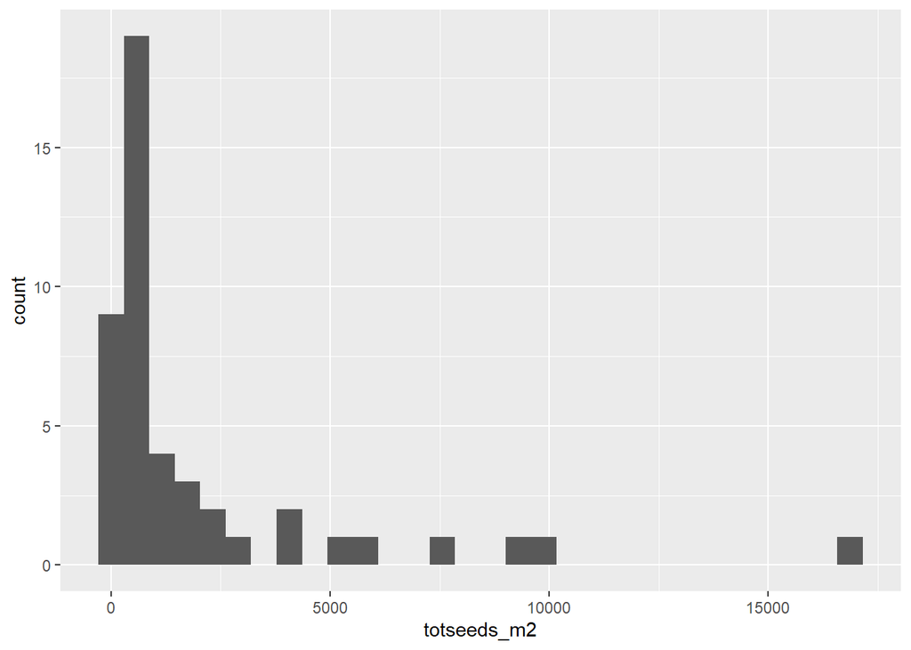

```r
dat %>%
  ggplot(aes(totseeds_m2)) +
  geom_histogram()
```

Because of this (I think it was because it was skewed), we fit our statistical models to a log-transformed response varible. Is there a better way to justify this? Looking at the residual plots, I am not sure there is a clear answer.

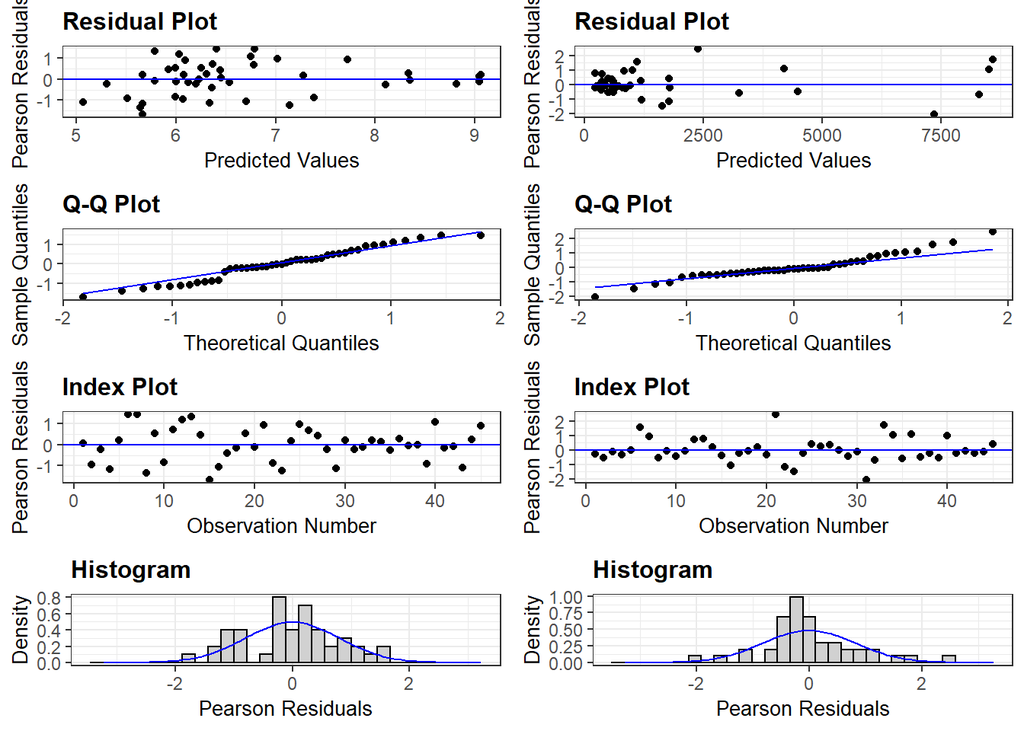

```r
library(ggResidpanel)

m1 <- lmer(log(totseeds_m2) ~ site_sys * cc_trt2 + (1|blockID), data = filter(dstat, totseeds_m2 < 15000))
m2 <- lmer((totseeds_m2) ~ site_sys * cc_trt2 + (1|blockID), data = filter(dstat, totseeds_m2 < 15000))

ggResidpanel::resid_compare(list(m1, m2))
```

Pretending the log-transformed response variable is the best…

I fit my model:

```r
m1 <- lmer(log(totseeds_m2) ~ site_sys * cc_trt2 + (1|blockID), data = filter(dstat, totseeds_m2 < 15000))
```

Now I use the **emmeans** package to compare the rye/none treatments in each *site_sys*, and the **broom** package to make it tidy.

```r
m1em <- (emmeans(m1, pairwise ~ cc_trt2|site_sys, type = "response"))
m1res <- broom::tidy(m1em$contrasts)
m1res
```

| contrast | site_sys | ratio | std.error | df | statistic | p.value |
| --- | --- | --- | --- | --- | --- | --- |
| aryecc / none | Boyd_grain | 1.3951044 | 0.4031401 | 22.36305 | 1.1522715 | 0.26137897 |
| aryecc / none | Boyd_silage | 0.3903828 | 0.1595346 | 22.36305 | -2.3017247 | 0.03102711 |
| aryecc / none | Funcke_grain | 0.4910404 | 0.2504507 | 24.87705 | -1.3944548 | 0.17550972 |
| aryecc / none | Stout_grain | 0.6393175 | 0.2921029 | 22.36305 | -0.9791113 | 0.33799915 |

## Question

How should I interpret/report this ratio? For example, in the **Boyd_silage** *site_sys*:

```r
m1res %>%
  filter(site_sys == "Boyd_silage") %>%
  select(contrast, site_sys, ratio, p.value)
```

| contrast | site_sys | ratio | p.value |
| --- | --- | --- | --- |
| aryecc / none | Boyd_silage | 0.3903828 | 0.03102711 |

This means the *aryecc* treatment had 39% of the weeds as the *none* treatment? So rye reduces weed seedbanks by:

```r
(1-0.39)*100
```

```
## [1] 61
```

61%?

Alternatively, [emmeans offers something](https://cran.r-project.org/web/packages/emmeans/vignettes/transformations.html) that seems to deal with responses that were transformed.

This produces the same results as above:

```r
m1em_alt1 <- emmeans(m1, pairwise ~ cc_trt2|site_sys, type = "response")  #--ratio, must be default
broom::tidy(m1em_alt1$contrasts)
```

| contrast | site_sys | ratio | std.error | df | statistic | p.value |
| --- | --- | --- | --- | --- | --- | --- |
| aryecc / none | Boyd_grain | 1.3951044 | 0.4031401 | 22.36305 | 1.1522715 | 0.26137897 |
| aryecc / none | Boyd_silage | 0.3903828 | 0.1595346 | 22.36305 | -2.3017247 | 0.03102711 |
| aryecc / none | Funcke_grain | 0.4910404 | 0.2504507 | 24.87705 | -1.3944548 | 0.17550972 |
| aryecc / none | Stout_grain | 0.6393175 | 0.2921029 | 22.36305 | -0.9791113 | 0.33799915 |

```r
m1em_alt2 <- emmeans(m1, pairwise ~ cc_trt2|site_sys, type = "lp") #--log scale? back-transformed? confused
broom::tidy(m1em_alt2$contrasts)
```

| level1 | level2 | site_sys | estimate | std.error | df | statistic | p.value |
| --- | --- | --- | --- | --- | --- | --- | --- |
| aryecc | none | Boyd_grain | 0.3329693 | 0.2889677 | 22.36305 | 1.1522715 | 0.26137897 |
| aryecc | none | Boyd_silage | -0.9406276 | 0.4086621 | 22.36305 | -2.3017247 | 0.03102711 |
| aryecc | none | Funcke_grain | -0.7112289 | 0.5100409 | 24.87705 | -1.3944548 | 0.17550972 |
| aryecc | none | Stout_grain | -0.4473541 | 0.4568981 | 22.36305 | -0.9791113 | 0.33799915 |